# R Notebook

```r
library(ggplot2)
library(bayesrules)
library(tidyverse)
library(rstan)
library(rstanarm)
library(bayesplot)
library(tidybayes)
library(janitor)
library(broom.mixed)
library(palmerpenguins)
require(brms)
library(ggplot2)
library(mltools)
library(data.table)
```

```r
dfSecurities = read.csv("securities.csv")
dfFundamentals = read.csv("fundamentals.csv")
dfPrices = read.csv("prices.csv")

dfPricesAdjusted = read.csv("prices-split-adjusted.csv")
dfPricesAdjusted$date = as.Date(dfPricesAdjusted$date)
dfFundamentals$symbol = dfFundamentals$Ticker.Symbol
dfSecurities$symbol = dfSecurities$Ticker.symbol
```

```r
head(dfPricesAdjusted)
```

|  | date | symbol | open | close | low | high | volume |
| --- | --- | --- | --- | --- | --- | --- | --- |
| 1 | 2016-01-05 | WLTW | 123.43 | 125.84 | 122.31 | 126.25 | 2163600 |
| 2 | 2016-01-06 | WLTW | 125.24 | 119.98 | 119.94 | 125.54 | 2386400 |
| 3 | 2016-01-07 | WLTW | 116.38 | 114.95 | 114.93 | 119.74 | 2489500 |
| 4 | 2016-01-08 | WLTW | 115.48 | 116.62 | 113.50 | 117.44 | 2006300 |
| 5 | 2016-01-11 | WLTW | 117.01 | 114.97 | 114.09 | 117.33 | 1408600 |
| 6 | 2016-01-12 | WLTW | 115.51 | 115.55 | 114.50 | 116.06 | 1098000 |

Company Apple prices

```r
adjustedPricesApple = dfPricesAdjusted[dfPricesAdjusted$symbol=="AAPL",]

ApplePrices = dfPrices[dfPrices$symbol=="AAPL",]
```

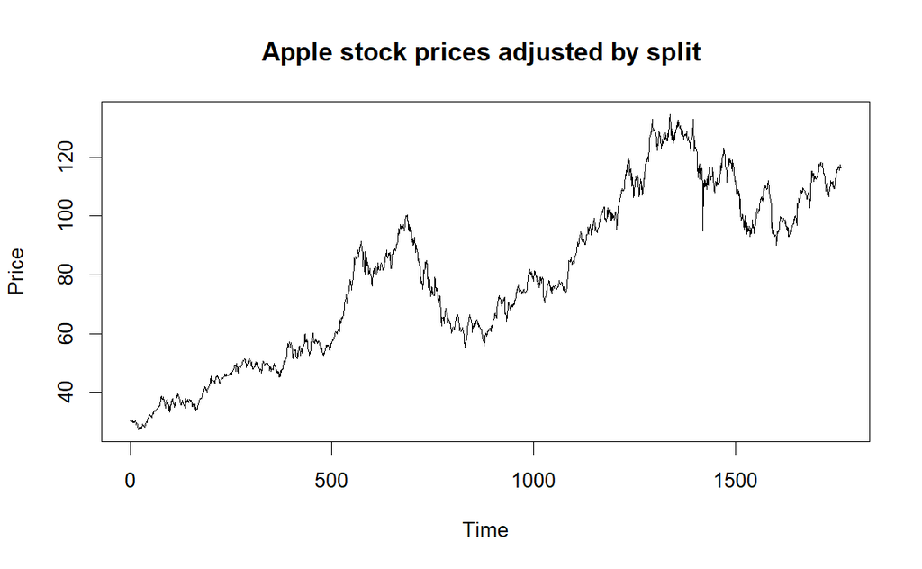

```r
plot(seq(1, length(adjustedPricesApple$date), by=1), adjustedPricesApple$open, type = "l", main="Apple stock prices adjusted by split ", xlab="Time", ylab="Price")
```

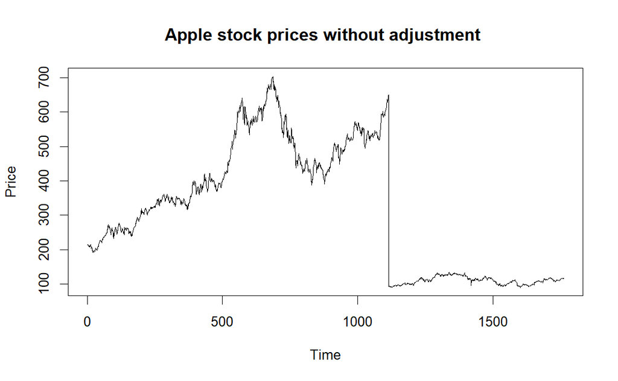

```r
plot(seq(1, length(ApplePrices$date), by=1), ApplePrices$open, type = "l",  main="Apple stock prices without adjustment ", xlab="Time", ylab="Price")
```

It is clear that we should only analize only the adjusted prices as the regular prices have the split anomalies that will interfere with the model predictions, even if they are very infrequent.

```r
dfAvgPriceDaysOperating = dfPricesAdjusted %>%
                           group_by(symbol) %>%
                           summarise(averageTrade = mean(open),
                           daysOperating = n_distinct(date)) %>%
                           arrange(averageTrade, daysOperating)

dfAvgPriceDaysOperating
```

| symbol | averageTrade | daysOperating |
| --- | --- | --- |
| FTR | 5.789523 | 1762 |
| HBAN | 8.116782 | 1762 |
| RF | 8.281322 | 1762 |
| ARNC | 9.024568 | 1762 |
| XRX | 9.993167 | 1762 |
| KEY | 10.747089 | 1762 |
| BSX | 11.427548 | 1762 |
| AES | 12.242968 | 1762 |
| NI | 13.065312 | 1762 |
| BAC | 13.584608 | 1762 |

[output cut: 491 more lines]

We can see that most companies from the 500 on the dataset have traded for 1762 days while around 30 companies have traded for less. In order to be consistent with the amount of information from each company we will discard the companies that don’t have 1762 days. We assume that this 30 companies prices are not a strong indicator of the future prices of the other 470 companies.

```r
dfCompaniesToTrack = dfAvgPriceDaysOperating[dfAvgPriceDaysOperating$daysOperating==1762,]
dfCompaniesToTrack <- dfCompaniesToTrack[c("symbol")]

dfPricesAdjustedCompanysToTrack = inner_join(dfPricesAdjusted, dfCompaniesToTrack, by = "symbol")
dfFundamentalsCompanysToTrack = inner_join(dfFundamentals, dfCompaniesToTrack, by = "symbol")
dfSecuritiesCompanysToTrack = inner_join(dfSecurities, dfCompaniesToTrack, by = "symbol")
```

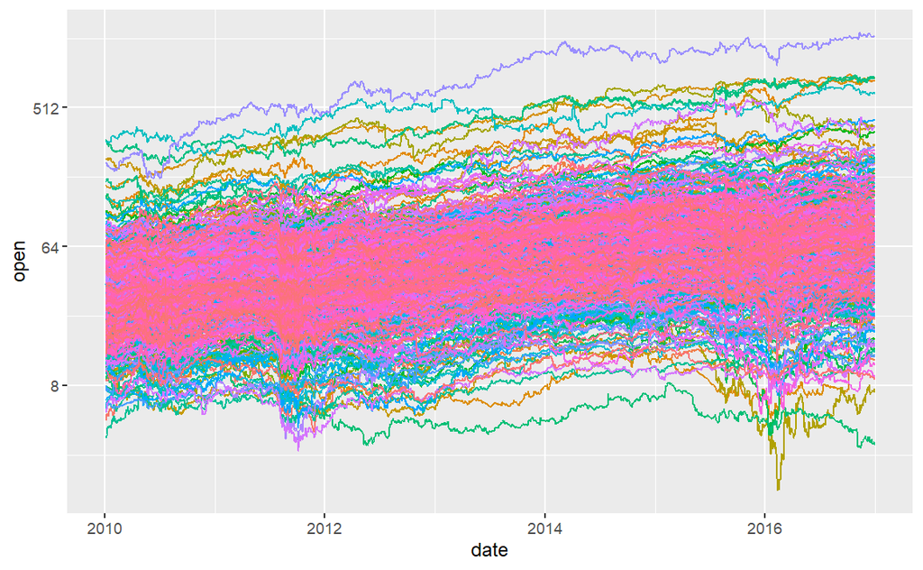

```r
p = ggplot(data=dfPricesAdjustedCompanysToTrack, aes(x=date, y=open, group=symbol)) +
  geom_line(aes(color=symbol))
  #geom_point(aes(color=symbol))
p + theme(legend.position="none") + scale_y_continuous(trans='log2')
```

We plotted the prices from all the companies in time with logharitmic scale on the price axis.

```r
sum(is.na(dfPricesAdjustedCompanysToTrack))
```

```
[1] 0
```

```r
sum(is.na(dfSecuritiesCompanysToTrack))
```

```
[1] 0
```

```r
sum(is.na(dfFundamentalsCompanysToTrack))
```

```
[1] 1358
```

As we can see there are only nil values on the fundamentals let’s explore those to see what we are missing.

```r
nan_counts <- colSums(is.na(dfFundamentalsCompanysToTrack))
nan_counts <- nan_counts[nan_counts!=0]
(nan_counts)
```

```
                  Cash.Ratio                Current.Ratio                  Quick.Ratio
                         284                          284                          284
                    For.Year           Earnings.Per.Share Estimated.Shares.Outstanding
                         142                          182                          182
```

```r
view(dfFundamentalsCompanysToTrack)
```

We will define what we do with those later on.

Lets consider 3 variables. The period of time we want to keep our investment, minimum porcentage of return after that time period, and maximum volatility which is the standar deviation of the stock price in terms of change in the time period.

so of any given stock averageReturn = meanOfd(price[d+timePeriod]/price[d]) notice that average return is not the same as return if we keep it from end to end. because if we start with 100$ with a time period of a day and lose -35% then gain 50% we would still be losing on absolute value, even though our averageReturn is 7.5%

```r
timePeriod5Days = 5
timePeriod30Days = 30
```

```r
calculatePorcentagesOfReturn = function (dataFramePrices, timePeriod){

  dfPricesPorcentagedayPeriod = copy(dataFramePrices)

   dfPricesPorcentagedayPeriod$porcentage = -10000
  for (i in c(1:(nrow(dfPricesPorcentagedayPeriod)))){
    currentDay =  dfPricesPorcentagedayPeriod[i,]$date
    stockSymbol = dfPricesPorcentagedayPeriod[i,]$symbol

    precioDespuesTiempo = dataFramePrices[dataFramePrices$date==currentDay+timePeriod & dataFramePrices$symbol==stockSymbol,]

    precioActual = dataFramePrices[i,]$open

    #print("precio post :")
    #print(precioDespuesTiempo)
    #print(i)
    if(nrow(precioDespuesTiempo)>0){
          dfPricesPorcentagedayPeriod[i,]$porcentage = (precioDespuesTiempo$open) / precioActual

    }
    #if(i%%100==0){
    #  print(i)
    #}
  }
   dfPricesPorcentagedayPeriod = dfPricesPorcentagedayPeriod[dfPricesPorcentagedayPeriod$porcentage>-9999,]
   return(dfPricesPorcentagedayPeriod)
}
```

```r
calculatePorcentagesMultipleDays = function(df, timePeriod1,timePeriod2,timePeriod3 ){
  df = calculatePorcentagesOfReturn(df, timePeriod1)
  df <- df %>%
       rename("porcentageTimePer1" = "porcentage" )
  df = calculatePorcentagesOfReturn(df, timePeriod2)
  df <- df %>%
       rename("porcentageTimePer2" = "porcentage")
  df = calculatePorcentagesOfReturn(df, timePeriod3)
  df <- df %>%
       rename("porcentageTimePer3" = "porcentage")
  return(df)

}
```

```r
dfApple = dfPricesAdjustedCompanysToTrack[dfPricesAdjustedCompanysToTrack$symbol=="AAPL",]
dfGoogle = dfPricesAdjustedCompanysToTrack[dfPricesAdjustedCompanysToTrack$symbol=="GOOGL",]
dfMicrosoft = dfPricesAdjustedCompanysToTrack[dfPricesAdjustedCompanysToTrack$symbol=="MSFT",]
dfNike = dfPricesAdjustedCompanysToTrack[dfPricesAdjustedCompanysToTrack$symbol=="NKE",]

dfApple5Days = calculatePorcentagesOfReturn(dfApple, 5)
dfApple30Days = calculatePorcentagesOfReturn(dfApple, 30)
dfApple200Days = calculatePorcentagesOfReturn(dfApple, 200)
dfGoogle5Days = calculatePorcentagesOfReturn(dfGoogle, 5)
dfGoogle30Days = calculatePorcentagesOfReturn(dfGoogle, 30)
dfGoogle200Days = calculatePorcentagesOfReturn(dfGoogle, 200)
dfMicrosoft5days = calculatePorcentagesOfReturn(dfMicrosoft, 5)
dfMicrosoft30days = calculatePorcentagesOfReturn(dfMicrosoft, 30)
dfMicrosoft200days = calculatePorcentagesOfReturn(dfMicrosoft, 200)
dfNike5Days = calculatePorcentagesOfReturn(dfNike, 5)
dfNike30Days = calculatePorcentagesOfReturn(dfNike, 30)
dfNike200Days = calculatePorcentagesOfReturn(dfNike, 200)
```

```r
plot(dfApple200Days$date, dfApple200Days$porcentage-1,
    type="l", col="green", xlim=c(min(dfApple200Days$date), max(dfApple5Days$date)),
    main="Return porcentage with different time windows for Apple stock", xlab="Date", ylab="Return Porcentage")

lines(dfApple30Days$date, dfApple30Days$porcentage-1, col="yellow")
```

```r
lines(dfApple5Days$date, dfApple5Days$porcentage-1,  col="red")
legend("topright", legend=c("5 days", "30 days", "200 days"), lwd=3, col= c("red","yellow","green"))
```

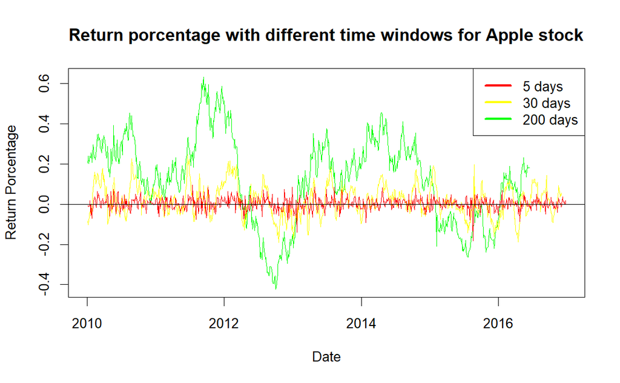

```r
abline(0,0)
```

```r
abline(0,0)
```

```
Error in int_abline(a = a, b = b, h = h, v = v, untf = untf, ...) :
  plot.new has not been called yet
```